G34-gliomas project [[source](https://github.com/fungenomics/G34-gliomas)]

# 03 - Co-expression of astrocyte and interneuron programs in normal brain and tumor cells

21 July, 2021

# 1 Configuration

Configuration of project directory & analysis outputs:

**Show full config**

```r
library(here)

# Set up outputs
message("Document index: ", doc_id)
```

```
## Document index: 03
```

```r
# Specify where to save outputs
out        <- here(subdir, "output", doc_id); dir.create(out, recursive = TRUE)
figout     <- here(subdir, "figures", doc_id, "/"); dir.create(figout, recursive = TRUE)
cache      <- paste0("~/tmp/", basename(here()), "/", subdir, "/", doc_id, "/")

message("Cache: ", cache)
```

```
## Cache: ~/tmp/G34-gliomas/singlecell_normal/03/
```

The root directory of this project is:

```
## /lustre03/project/6004736/sjessa/from_beluga/HGG-G34/G34-gliomas
```

Outputs and figures will be saved at these paths, relative to project root:

```
## G34-gliomas/singlecell_normal/output/03
```

```
## G34-gliomas/singlecell_normal/figures/03//
```

Setting a random seed:

```r
set.seed(100)
```

# 2 Overview

Given that we a dual neuronal-astrocytic gene expression program in the tumors, here we interrogate the expression of interneuron and astrocytic gene signatures in the normal brain, and then evaluate the same signatures in the tumors, to understand if this is an aberrant state, or also observed under normal conditions.

For each dataset:

1. Take the mean expression each of an interneuron gene signature and an astrocyte signature
2. Subset to cells which are astrocytes, interneurons, or radial glia
3. Generate a scatterplot of cells based on their expression of the two signatures

# 3 Libraries

```r
# Load liraries here
library(here)
library(tidyr)
library(dplyr)
library(glue)
library(ggplot2)
library(purrr)
library(readr)
library(Seurat)
```

# 4 Load data

Human fetal brain (5-37 PCW, Nowakowski et al, Science, 2017):

```r
load(here("reference_datasets/2017_Nowakowski/processed_data/nowakowski_seurat.Rda"))
```

Prepare the palette for this dataset, so that astrocytes, internurons, and radial glial cells are distinct:

```r
palette_nowakowski <- read_csv(here("reference_datasets/2017_Nowakowski/processed_data/nowakowski2017_tableS4_cluster_labels_with_colours.csv")) %>%
  select(Cluster = `Cluster Name`, colour = Colour) %>%
  tibble::deframe()
palette_nowakowski["Astrocyte"] <- "#FF3F38"
palette_nowakowski[grepl("RG", names(palette_nowakowski))] <- "#ffcc00"
```

Mouse developing forebrain (E12-P6)

```r
load(here("reference_datasets/2019_Jessa/Jessa2019_forebrain_seurat.Rda"))
```

Prepare palette:

```r
palette_atlas <- read_tsv(here("reference_datasets/2019_Jessa/Jessa2019_Table_2a.tsv")) %>%
  select(Cluster, Colour) %>%
  mutate(Cluster = gsub("_", " ", Cluster)) %>%
  tibble::deframe()
palette_atlas[grepl("ASTR",      names(palette_atlas))] <- "#FF3F38"
palette_atlas[grepl("VRGC",      names(palette_atlas))] <- "#ffcc00"
palette_atlas[grepl("MGIN|CINH", names(palette_atlas))] <- "#084081"
```

# 5 Analysis

## 5.1 Get gene signatures

Here, we’ll get the leading edge genes from the GSEA analysis, for one human interneuron signature and one astrocyte signature, both enriched in G34R/V tumors.

```r
dge_le <- read_tsv(here("bulk_transcriptome_epigenome/output/02/fgsea_results_padj<0.01_IDH_top_le.tsv"))
load(here("reference_datasets/2017_Nowakowski/processed_data/nowakowski_signatures.Rda"))

# Newborn interneuron signature
interneuron_genes    <- nowakowski_signatures$hg_sym$nIN1
interneuron_genes_mm <- nowakowski_signatures$mm_sym$nIN1

# Astrocyte signature
astro_genes          <- nowakowski_signatures$hg_sym$Astrocyte
astro_genes_mm       <- nowakowski_signatures$mm_sym$Astrocyte
```

## 5.2 Human fetal telencephalon (Nowakowski et al, 2017)

```r
data_nowakowski <- data.frame(
  interneuron_signature = cytobox::meanGeneExpression(nowa, interneuron_genes)$Mean_marker_expression,
  astrocyte_signature   = cytobox::meanGeneExpression(nowa, astro_genes)$Mean_marker_expression,
  cluster               = nowa@meta.data$WGCNAcluster,
  celltype              = nowa@meta.data$Cell_type
)

# Filter to cell types of interest for this analysis: astrocytes, inhibitory neurons
# and ganglionic eminence radial glia
data_nowakowski <- data_nowakowski %>%
  filter(cluster %in% c("Astrocyte",
                        "nIN1", "nIN2", "nIN3", "nIN4",
                        "IN-CTX-CGE1", "IN-CTX-MGE1",
                        "MGE-IPC1", "MGE-IPC2", "MGE-IPC3",
                        "MGE-RG1", "MGE-RG2", "MGE-div"))

# Clean up
rm(nowa)
```

Generate the scatterplot:

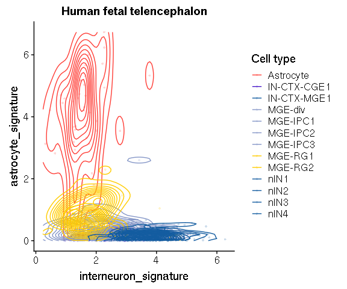

```r
data_nowakowski %>%
  rr_ggplot(aes(x = interneuron_signature, y = astrocyte_signature, colour = cluster), plot_num = 1) +
  geom_point(shape = 16, size = 1, alpha = 0.2) +
  scale_color_manual(values = palette_nowakowski, name = "Cell type") +
  geom_density_2d() +
  ggtitle("Human fetal telencephalon")
```

<sub>[figure/source data @ *G34-gliomas/singlecell_normal/figures/03//nowakowski_scatterplot…*]</sub>

## 5.3 Developing mouse forebrain (Jessa et al, 2019)

In the mouse atlas:

```r
data_atlas <- data.frame(
  interneuron_signature = cytobox::meanGeneExpression(joint_cortex_small, interneuron_genes_mm)$Mean_marker_expression,
  astrocyte_signature   = cytobox::meanGeneExpression(joint_cortex_small, astro_genes_mm)$Mean_marker_expression,
  cluster               = gsub("_", " ", joint_cortex_small@meta.data$ID_20190730_with_blacklist_and_refined)
)
```

```
## NOTE: [Best3, 5830418K08Rik] undetected in Forebrain E12.5
```

```
## NOTE: [NA, Sirpb1c, Gm9733, Sirpb1a, Gm5150, B3galtl, Pmp2] undetected in Forebrain E12.5
```

```r
# Filter to relevant cell tpyes
data_atlas <- data_atlas %>%
  filter(grepl("ASTR|VRGC|MGIN|CINH|INIP", cluster) & !grepl("BLACKLIST", cluster))

# Clean up
rm(joint_cortex_small)
```

Plot:

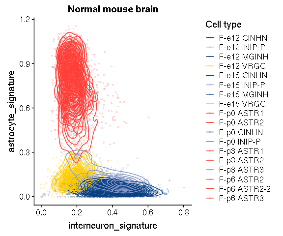

```r
data_atlas %>%
  rr_ggplot(aes(x = interneuron_signature, y = astrocyte_signature, colour = cluster), plot_num = 1) +
  geom_point(shape = 16, size = 1, alpha = 0.2) +
  scale_color_manual(values = palette_atlas, name = "Cell type") +
  geom_density_2d() +
  ggtitle("Normal mouse brain")
```

<sub>[figure/source data @ *G34-gliomas/singlecell_normal/figures/03//mouse_forebrain_scatter…*]</sub>

## 5.4 H3G34R/V tumors

Load Seurat object with all samples combined, and re-constitute a V2 object from the V3 object:

```r
load("/lustre03/project/6004736/vlisi/fromHydra/SCRATCH/vlisi/LEGACY/G34/inHouseDataCombined/data/integrated_g34.seurat_v3.save_v2.Rda")

# get cell type projections used in Figure 5
load("/lustre03/project/6004736/vlisi/fromHydra/SCRATCH/vlisi/LEGACY/G34/allSamplesCombined/data/ScSnMetaDataWithNormals.RDat")
cell_meta <- ScSnDataWithNormals

# convert the object to V3
seurat_joint <- CreateSeuratObject(raw.data = integrated_g34@assays$RNA@counts,
                                   meta.data = integrated_g34@meta.data)
seurat_joint <- NormalizeData(seurat_joint)
seurat_joint <- SetDimReduction(seurat_joint, reduction.type = "umap", slot = "cell.embeddings",
                                integrated_g34@reductions[["umap"]]@cell.embeddings)
seurat_joint <- SetDimReduction(seurat_joint, reduction.type = "umap", slot = "key", "UMAP_")

# add in the cell type projections used in Figure 5
seurat_joint <- AddMetaData(seurat_joint, ScSnDataWithNormals[, c("ConsensusLineageRefinedConsensus"), drop = FALSE])
seurat_joint@meta.data$Cell_type_projection <- seurat_joint@meta.data$ConsensusHybrid2L3NP.smoothk10
seurat_joint@meta.data$Cell_type_broad_Fig5 <- seurat_joint@meta.data$ConsensusLineageRefinedConsensus
seurat_joint@meta.data$Status_normal_malignant <- seurat_joint@meta.data$CNVnormals

seurat_joint@meta.data <- seurat_joint@meta.data[, c(colnames(seurat_joint@meta.data)[1:22],
                                                     "Status_normal_malignant",
                                                     "Cell_type_projection",
                                                     "Cell_type_broad_Fig5")]

# clean up
rm(integrated_g34)
rm(ScSnDataWithNormals)

save(seurat_joint, file = glue("{out}/integrated_seurat.Rda"))
```

```r
load(glue("{out}/integrated_seurat.Rda"))
```

Subset the same signatures used in the normal brain to the genes detected in the tumors:

```r
interneuron_genes_keep <- base::intersect(interneuron_genes, rownames(seurat_joint@data))
astro_genes_keep <- base::intersect(astro_genes, rownames(seurat_joint@data))
```

Calculate mean expression:

```r
data_tumors <- data.frame(
  interneuron_signature = cytobox::meanGeneExpression(seurat_joint, interneuron_genes_keep)$Mean_marker_expression,
  astrocyte_signature   = cytobox::meanGeneExpression(seurat_joint, astro_genes_keep)$Mean_marker_expression,
  cluster_broad         = seurat_joint@meta.data$Cell_type_broad_Fig5
)
```

Plot:

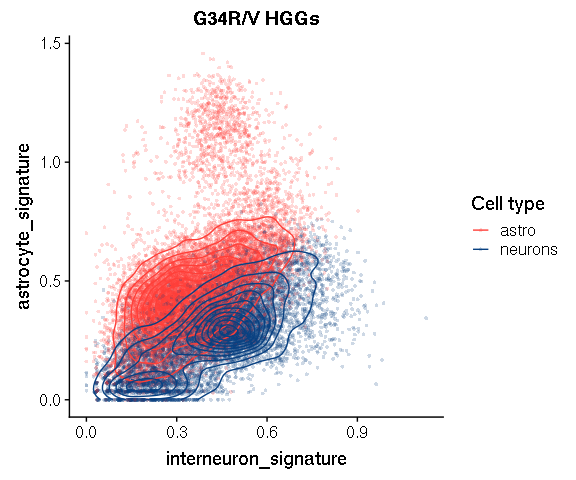

```r
data_tumors %>%
  filter(cluster_broad %in% c("neurons", "astro")) %>%
  rr_ggplot(aes(x = interneuron_signature, y = astrocyte_signature, colour = cluster_broad), plot_num = 1) +
  geom_point(shape = 16, size = 1, alpha = 0.2) +
  scale_color_manual(values = c("astro" = "#FF3F38", "neurons" = "#084081"), name = "Cell type") +
  geom_density_2d() +
  ggtitle("G34R/V HGGs")
```

<sub>[figure/source data @ *G34-gliomas/singlecell_normal/figures/03//tumor_scatter…*]</sub>

# 6 Reproducibility

This document was last rendered on:

```
## 2021-07-21 10:30:46
```

The git repository and last commit:

```
## Local:    master /lustre03/project/6004736/sjessa/from_beluga/HGG-G34/G34-gliomas
## Remote:   master @ origin (git@github.com:fungenomics/G34-gliomas.git)
## Head:     [677ad1b] 2020-12-11: Update & clean up - Update paths - Add pointers to figures in the README - Output final set of signatures used
```

The random seed was set with `set.seed(100)`

A project of the Kleinman Lab at McGill University, using the [rr](https://github.com/sjessa/rr/) reproducible research template.  
[home](https://functionalgenomics.ca/) [GitHub](https://github.com/fungenomics/)